# Soils contaminated with dieldrin since three decades

CK

20/08/2020

# Method briefly:

A paddock consisting of organic matter rich pasture soil with high residue concentrations of the legacy pollutant dieldrin was sampled in August 2018 (0-10 cm). Dieldrin was the main use of control for the ‘name?’ beetle in potato cropping until 1987. Total dieldrin dissipation in this surface soil was 50% since 1988 and remaining extractable residues in 2017 were 1.16 µg g-1 soil dry weight (± 0.07 SE) (Krohn et al. 2019). Minor concentrations of dichlorodiphenyltrichloroethane including its congener dichlorodiphenyldichloroethylene were also detected (0.11 µg g-1 soil dry weight (± 0.01 SE) (Krohn et al. 2019).

Analysis was done in two parts:  
- **T0－T39** From day of treatment to 9 months after treatment  
- **T39－T52** New treatment at 9 months and incubated for another 3 months reaching a total of 12 months. The new treatment was ‘ploughing’, i.e. aggregates were broken up. Additionally the organic substrates were re-applied.

# Result highlights

- Addition of labile carbon appeared to inhibit dieldrin dissipation
  - In general, the more microorganisms respired the less dieldrin dissipated. (Fig. 4, 7 and 11)
- Poultry litter inhibited dieldrin dissipation while poultry litter biochar did not
- Soils treated with poultry litter biochar contained lowest extractable dieldrin residues at the end of the incubation
- After re-applying the organic substrates in week 39, high respiration again correlated with low dieldrin dissipation (Fig. 10)
- Fumaric acid was an exception. It somehow suppressed respiration after 2nd application in week 39 and also suppressed dieldrin loss from week 39 onward (Fig. 8)
- The initial respiration response to treatments was most indicative for dieldrin dissipation as the strongest correlations of accumulated respiration was in week 4 - 8. In other words where microbes respired the most after treatment, the least dieldrin dissipated.

# Dieldrin concentrations summary

| Week | variable | n | mean | se |
| --- | --- | --- | --- | --- |
| re | Dieldrin | 6 | 1.162 | 0.012 |
| T0 | Dieldrin | 43 | 1.076 | 0.009 |
| T16 | Dieldrin | 44 | 1.057 | 0.010 |
| T39 | Dieldrin | 44 | 1.053 | 0.010 |
| T52 | Dieldrin | 44 | 0.950 | 0.008 |

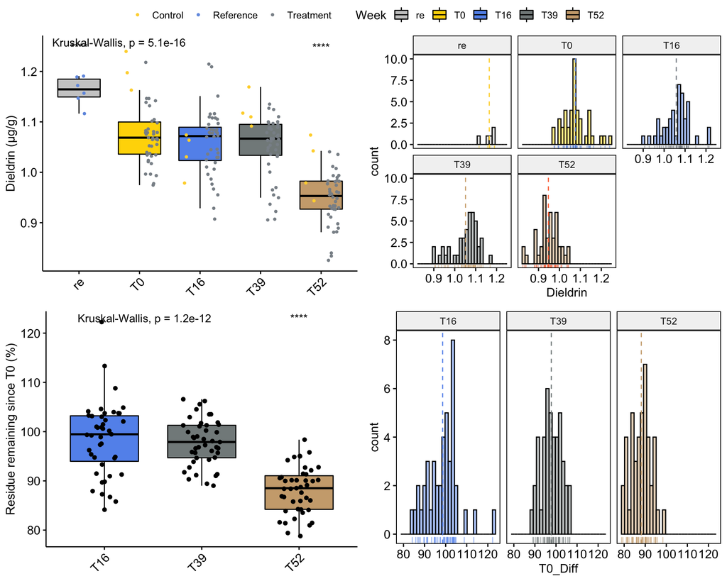

Figure 1: Boxplots of dieldrin concentrations and dieldrin concentrations relative to start of experiment (T0), including histograms.

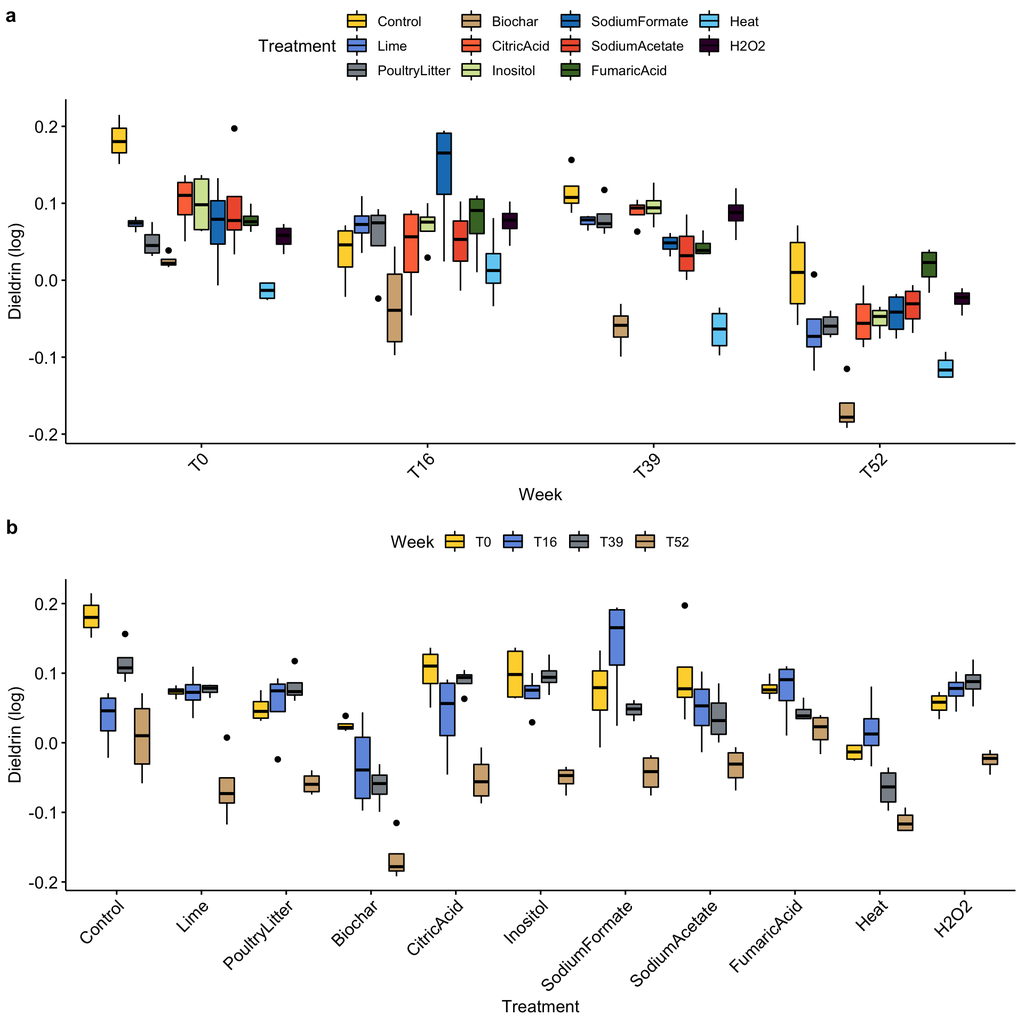

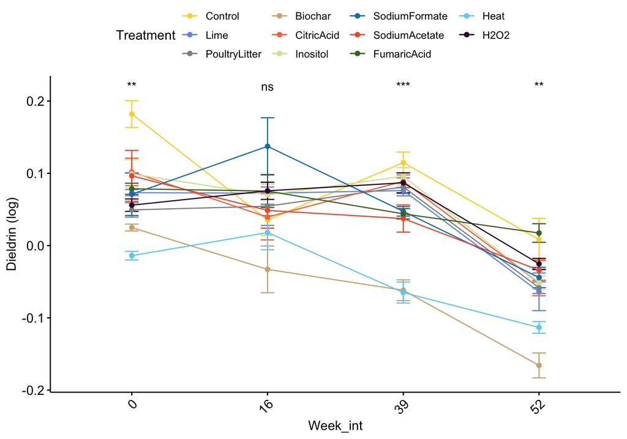

Figure 3: Dieldrin concentrations (log) across time. Error bars show the standard error of the mean of four replicates.

The treatment-comparison of dieldrin concentrations showed that biochar and the heat treatment were significantly lower compared to the control and all other treatments. It was also apparent the the biochar and heat treatment contained soil with lowest dieldrin concentrations from the start of the experiment. This meant that the effect of these treatments was immediate. For biochar this could be explained by lower extractability of dieldrin due to immediate sorption to biochar.

# Dieldrin loss correlations to respiration

## Accumulated respiration

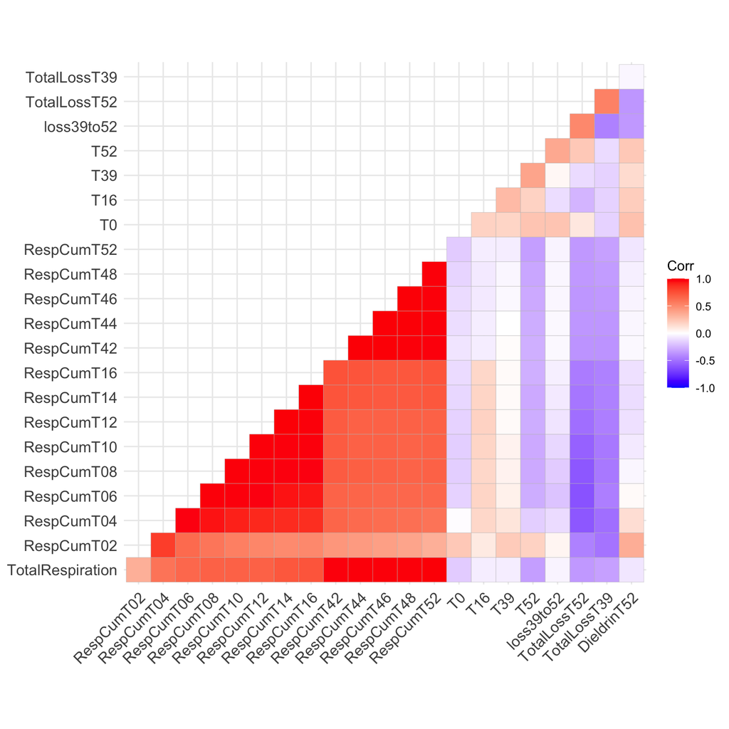

Figure 4: Correlations of total respiration (µg CO<sub>2</sub>-C g<sup>-1</sup> soil).

Accumulated respiration is correlated to total dieldrin loss. The higher the microbial respiration, the less dieldrin has dissipated. This was most pronounced with the respiration after 4-8 weeks, which correlated most strongly with the total dieldrin loss after 52 weeks (12 months).

# Part A, analysis of T0－T39

## Dieldrin loss

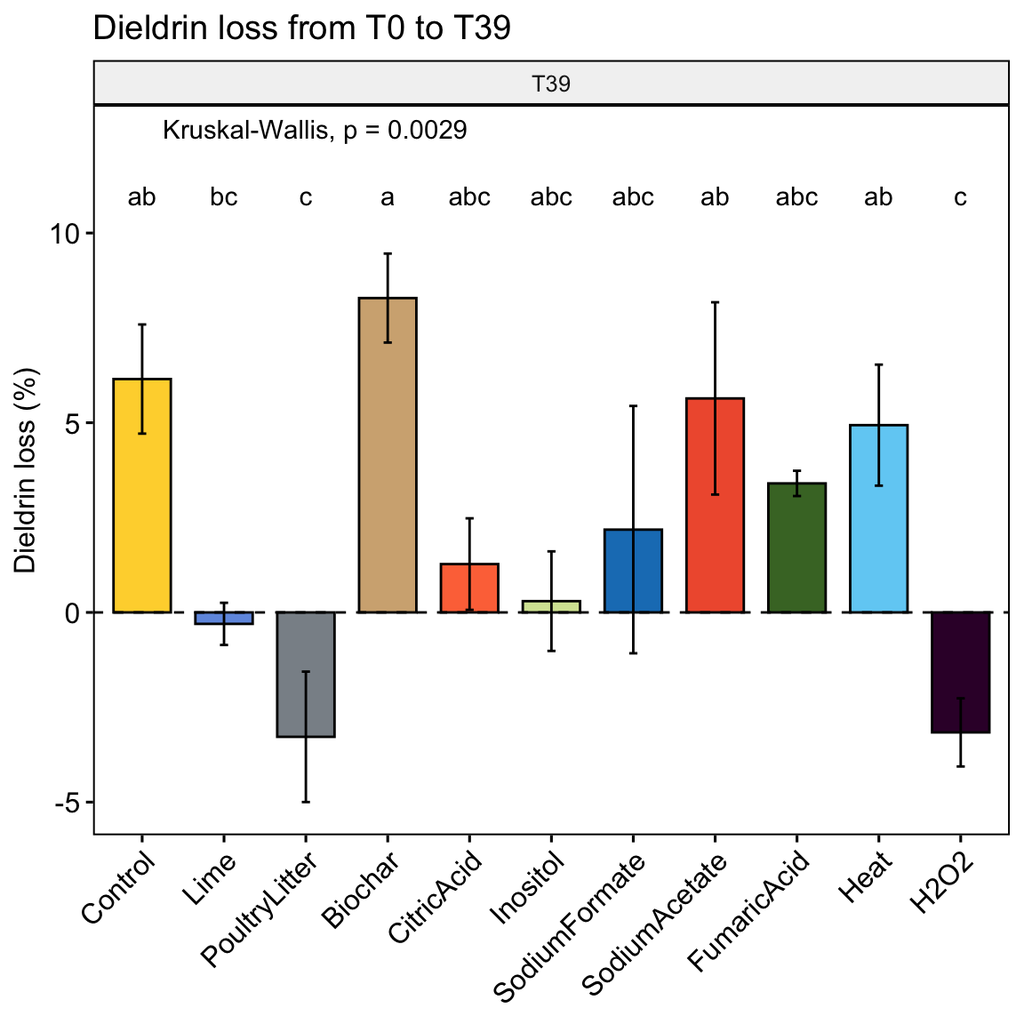

Figure 5: Residues loss in percent. Error bars show the standard error of the mean of four replicates. Letters show differences of the mean after multiple comparison tests (Fisher’s least significant difference, holm correct *p* value).

- Dieldrin concentrations of the treatments using poultry litter and hydrogen peroxide were slightly higher after 9 months (T39) resulting in negative loss. This could be due to (1) a change in solubility or extractability of dieldrin or (2) or due to general variability and therefore due to random chance. However, multiple comparisons using Fisher’s least significant difference (holm correct p value) indicated that these differences are unlikely due to random chance.
- Soils treated with biochar showed greatest mean dieldrin dissipation, followed by the no-treatment-control.

## Lineplots of respiration over time

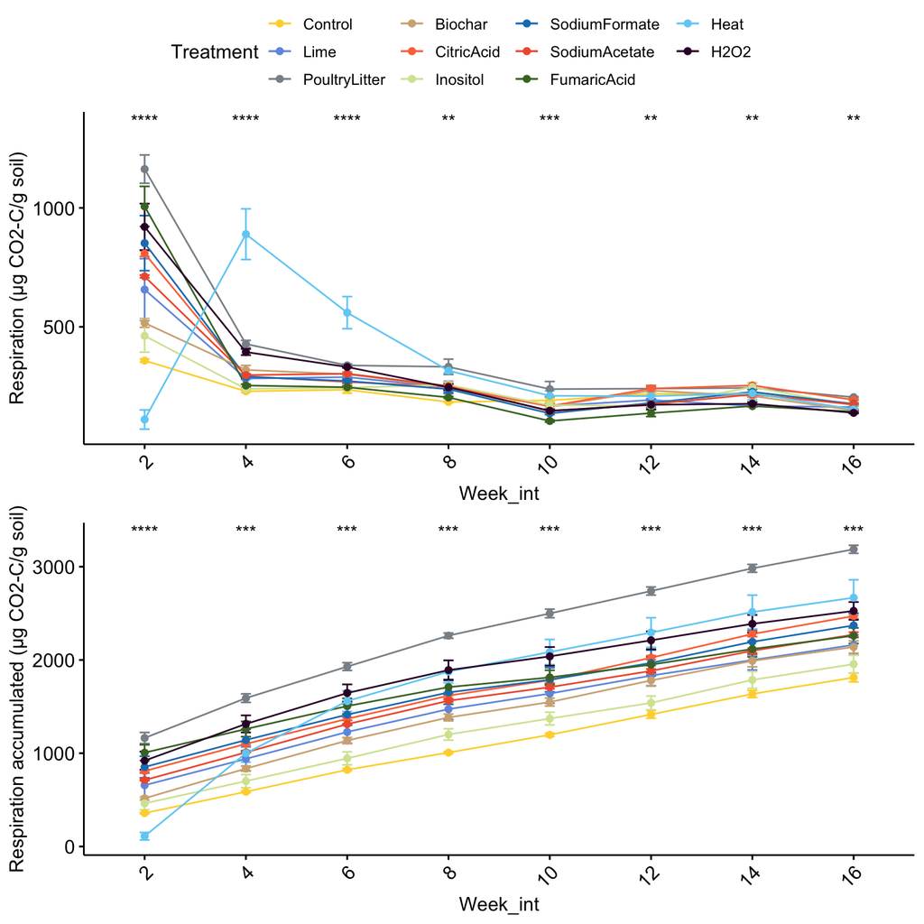

Figure 6: Respiration (µg CO<sub>2</sub>-C g<sup>-1</sup> soil) across time. Error bars show the standard error of the mean of four replicates.

- The treatments clearly affected microbial respiration.
- The heat treatment (3 x autoclaved at 135˚, dry) initially killed microbial organisms but the community recovered and gradually metabolised the heat-released carbon sources and was the treatment with the second highest total respiration after 16 weeks.

## Scatter plot of respiration to dieldrin loss (%)

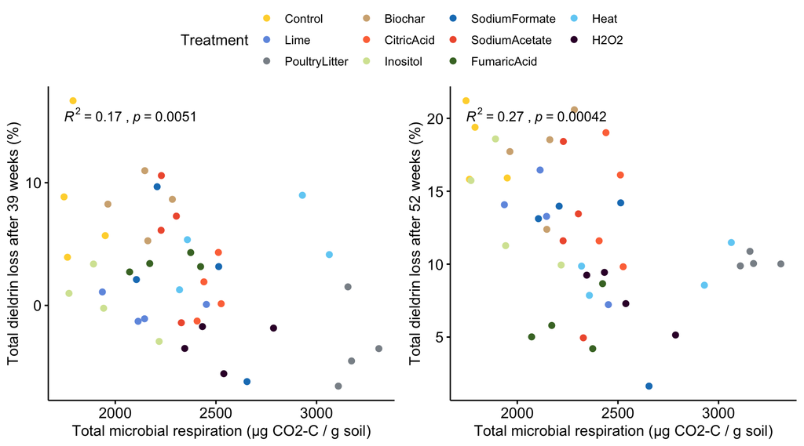

Figure 7: Scatterplot of total dieldrin loss (%) and total microbial respiration of the first 16 weeks (µg CO<sub>2</sub>-C g<sup>-1</sup> soil).

Respiration was calculated as the sum of the first 16 weeks of incubation (µg CO<sub>2</sub>-C g<sup>-1</sup> soil). Hence the microbial respiration was recorded for the first 4 months of incubation only.

- There was a negative relationship of total respiration and dieldrin loss (%). Dieldrin dissipated less in samples were microorganisms respired more carbon.
- This may be another hint that efficiency of carbon use may be linked to dieldrin degradation. Availability of soluble carbon appears to inhibit dieldrin metabolism.
- This relationship was stronger with total dieldrin losses after 12 months (which included the 3 months after mixing the soil).
- Perhaps the availability of soluble carbon primed a microbial community that favored fast growing r-strategists and therefore inhibited metabolism of stable carbon sources (with which dieldrin can be associated), even after soil was broken up.

# Part B analysis of T39－T52

## Dieldrin loss

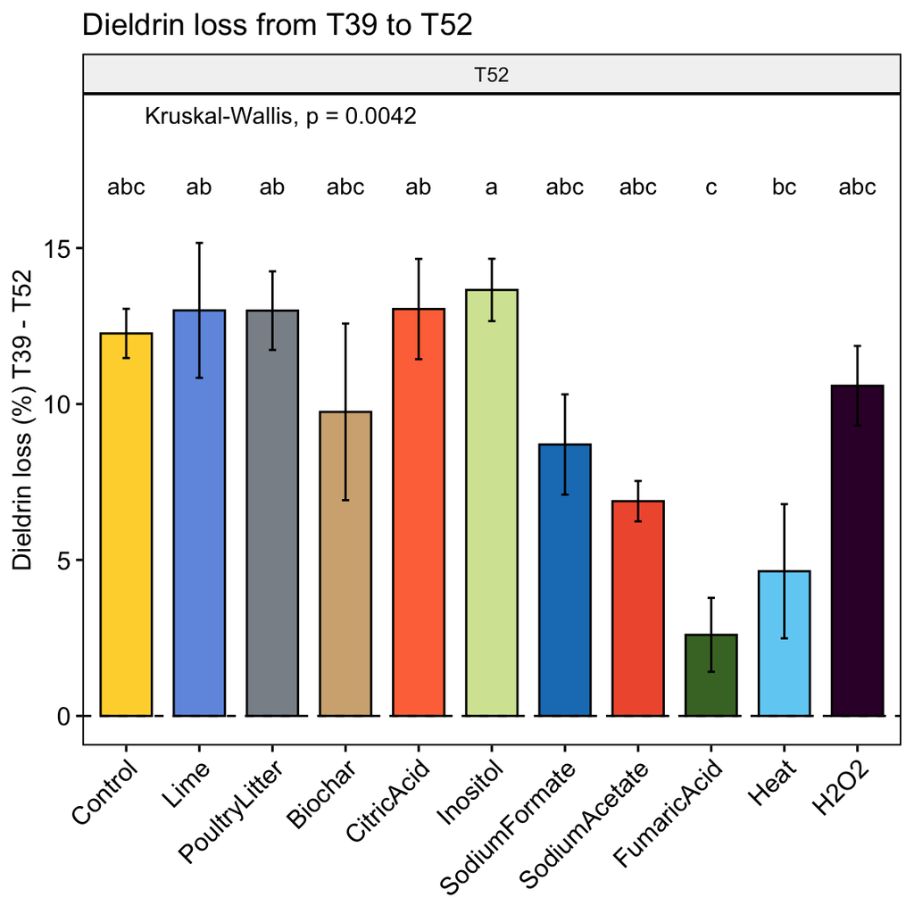

Figure 8: Residues loss in percent. At T39 the soil was ploughed inside the jars. Two timelines were therefore assessed separately (T0−T39 and T39−T52). Error bars show the standard error of the mean of four replicates. Letters show differences of the mean after multiple comparison tests (Fisher’s least significant difference, holm correct *p* value).

## Lineplots of respiration over time

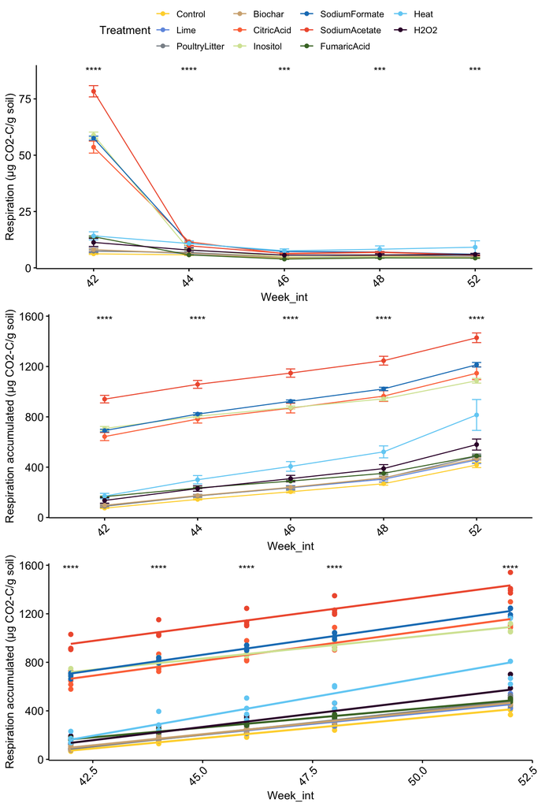

Figure 9: Respiration (µg CO<sub>2</sub>-C g<sup>-1</sup> soil) across time. Error bars show the standard error of the mean of four replicates.

## Scatter plot of respiration to dieldrin loss (%)

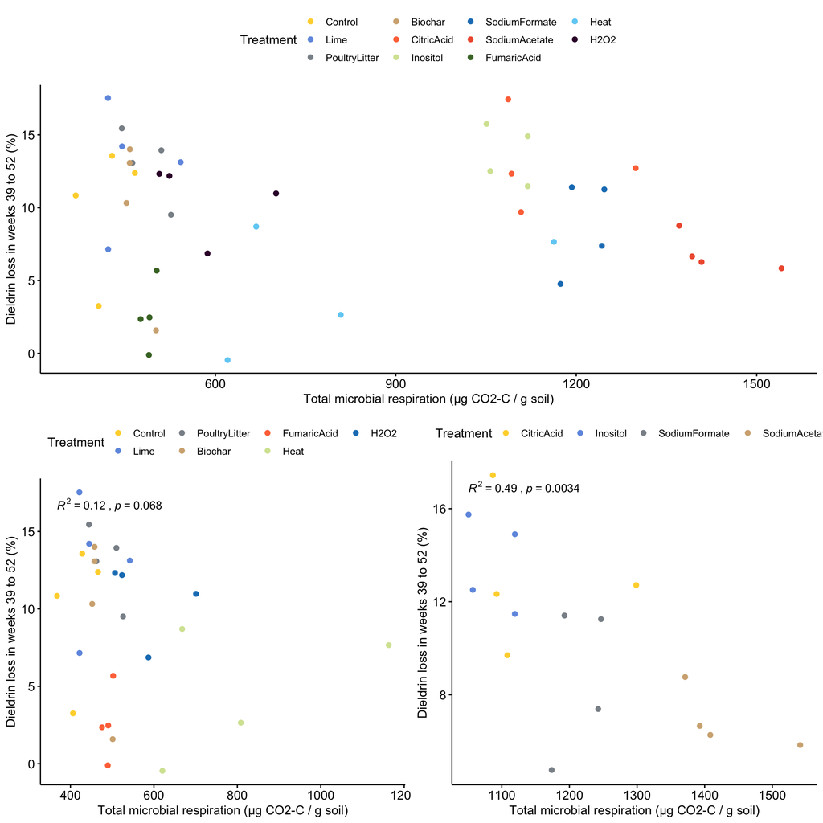

Figure 10: Scatterplot of total dieldrin loss (%) and total microbial respiration (µg CO<sub>2</sub>-C g<sup>-1</sup> soil) for weeks 42 to 52.

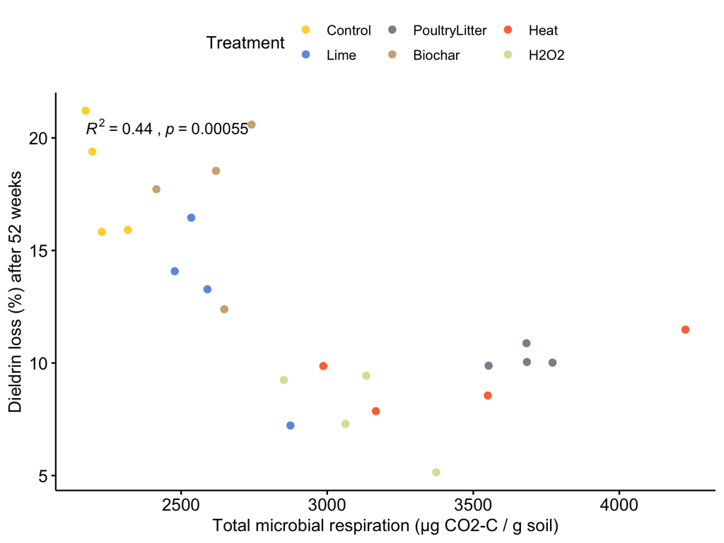

Figure 11: Scatterplot of total dieldrin loss (%) and total microbial respiration combined for weeks 1 - 16 and 42 to 52. Only treatments Control, Poultry Litter, Lime, Biochar, Heat and H202 are shown

# Part C analysis of T0－T52

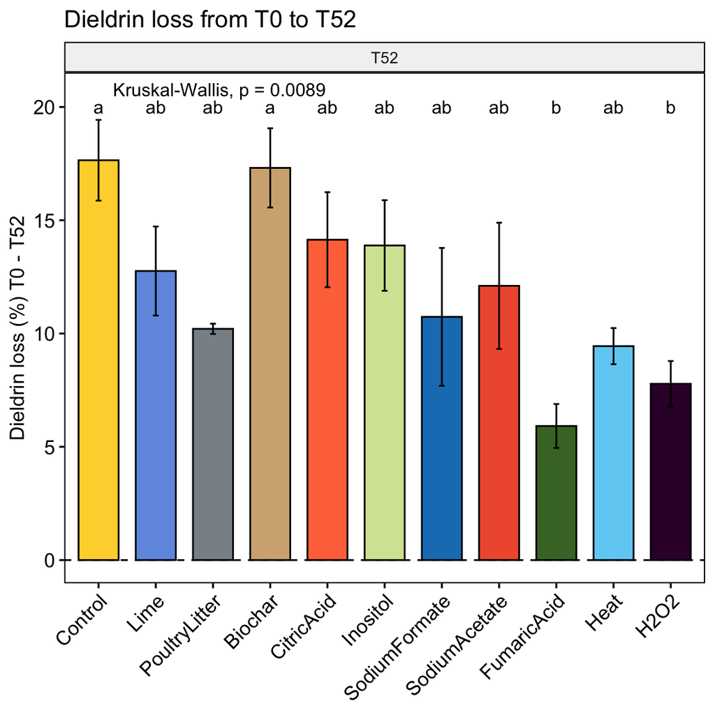

Figure 12: Residues loss in percent. Error bars show the standard error of the mean of four replicates. Letters show differences of the mean after multiple comparison tests (Fisher’s least significant difference, holm correct *p* value).

# Other analyses

## nMDS of GC/ECD peak areas

Peaks areas from analysis soil extracts (hexane:acetone 1:1) were normalised to an internal standard (DDD)

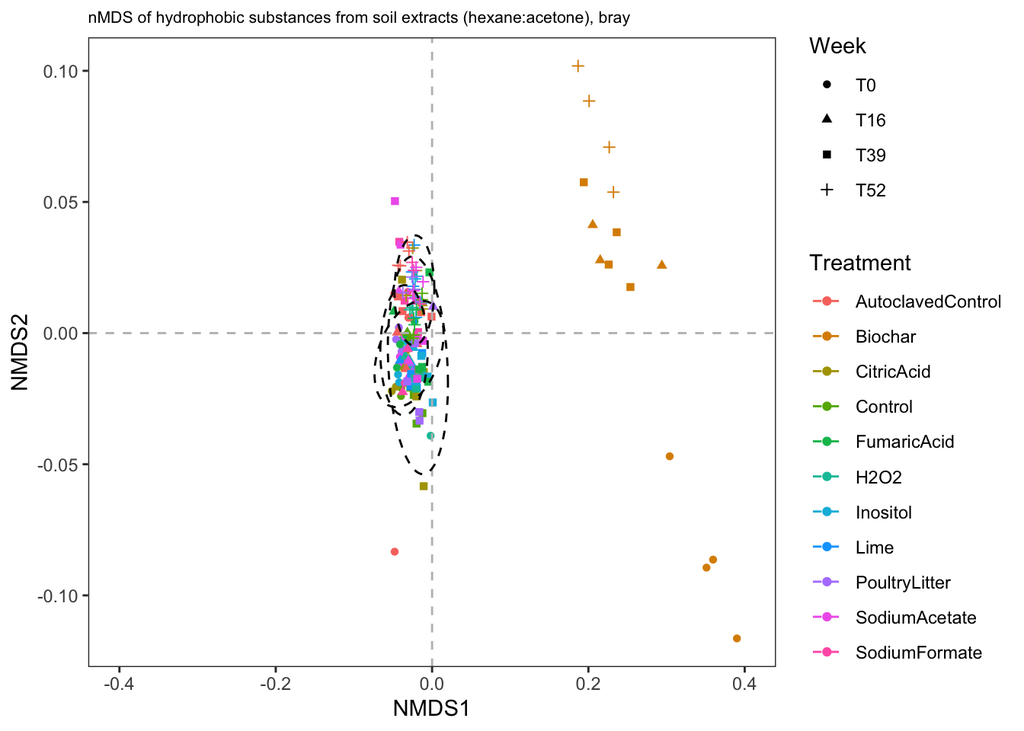

Figure 13: nMDS of peak areas of soil extracts (hexane:acetone 1:1).

The biochar resulted in significantly different composition of hydrophobic substances extracted from the soil. This composition has changed after the start of T0 but remained different to all other treatments.

## Table Summary

https://www.datanovia.com/en/lessons/repeated-measures-anova-in-r/

| Week | Treatment | variable | n | mean | se |
| --- | --- | --- | --- | --- | --- |
| re | Reference | Dieldrin | 6 | 1.162 | 0.012 |
| T0 | Control | Dieldrin | 3 | 1.200 | 0.022 |
| T0 | Lime | Dieldrin | 4 | 1.076 | 0.004 |
| T0 | PoultryLitter | Dieldrin | 4 | 1.051 | 0.010 |
| T0 | Biochar | Dieldrin | 4 | 1.025 | 0.005 |
| T0 | CitricAcid | Dieldrin | 4 | 1.108 | 0.021 |
| T0 | Inositol | Dieldrin | 4 | 1.105 | 0.022 |
| T0 | SodiumFormate | Dieldrin | 4 | 1.075 | 0.031 |
| T0 | SodiumAcetate | Dieldrin | 4 | 1.103 | 0.040 |
| T0 | FumaricAcid | Dieldrin | 4 | 1.082 | 0.008 |
| T0 | Heat | Dieldrin | 4 | 0.986 | 0.006 |
| T0 | H2O2 | Dieldrin | 4 | 1.058 | 0.009 |
| T16 | Control | Dieldrin | 4 | 1.037 | 0.021 |
| T16 | Lime | Dieldrin | 4 | 1.075 | 0.016 |
| T16 | PoultryLitter | Dieldrin | 4 | 1.057 | 0.027 |
| T16 | Biochar | Dieldrin | 4 | 0.969 | 0.032 |
| T16 | CitricAcid | Dieldrin | 4 | 1.042 | 0.032 |
| T16 | Inositol | Dieldrin | 4 | 1.073 | 0.016 |
| T16 | SodiumFormate | Dieldrin | 4 | 1.150 | 0.044 |
| T16 | SodiumAcetate | Dieldrin | 4 | 1.051 | 0.026 |
| T16 | FumaricAcid | Dieldrin | 4 | 1.079 | 0.024 |
| T16 | Heat | Dieldrin | 4 | 1.019 | 0.024 |
| T16 | H2O2 | Dieldrin | 4 | 1.079 | 0.013 |
| T39 | Control | Dieldrin | 4 | 1.122 | 0.017 |
| T39 | Lime | Dieldrin | 4 | 1.079 | 0.005 |
| T39 | PoultryLitter | Dieldrin | 4 | 1.085 | 0.014 |
| T39 | Biochar | Dieldrin | 4 | 0.940 | 0.013 |
| T39 | CitricAcid | Dieldrin | 4 | 1.093 | 0.010 |
| T39 | Inositol | Dieldrin | 4 | 1.101 | 0.013 |
| T39 | SodiumFormate | Dieldrin | 4 | 1.049 | 0.007 |
| T39 | SodiumAcetate | Dieldrin | 4 | 1.039 | 0.020 |
| T39 | FumaricAcid | Dieldrin | 4 | 1.045 | 0.008 |
| T39 | Heat | Dieldrin | 4 | 0.937 | 0.014 |
| T39 | H2O2 | Dieldrin | 4 | 1.091 | 0.015 |
| T52 | Control | Dieldrin | 4 | 1.010 | 0.030 |
| T52 | Lime | Dieldrin | 4 | 0.939 | 0.025 |
| T52 | PoultryLitter | Dieldrin | 4 | 0.943 | 0.008 |
| T52 | Biochar | Dieldrin | 4 | 0.848 | 0.015 |
| T52 | CitricAcid | Dieldrin | 4 | 0.950 | 0.017 |
| T52 | Inositol | Dieldrin | 4 | 0.950 | 0.009 |
| T52 | SodiumFormate | Dieldrin | 4 | 0.957 | 0.013 |
| T52 | SodiumAcetate | Dieldrin | 4 | 0.967 | 0.013 |
| T52 | FumaricAcid | Dieldrin | 4 | 1.018 | 0.013 |
| T52 | Heat | Dieldrin | 4 | 0.893 | 0.007 |
| T52 | H2O2 | Dieldrin | 4 | 0.975 | 0.007 |

# References

Krohn, Christian, Jian Jin, John Ryan, Piotr Fabijański, Ashley E. Franks, and Caixian Tang. 2019. “Composition of soil organic matter drives total loss of dieldrin and dichlorodiphenyltrichloroethane in high-value pastures over thirty years.” *Science of the Total Environment* 691: 135–45. https://doi.org/10.1016/j.scitotenv.2019.06.497.